# Semivariograms part 1

Daniel M. Parker (w/ help from ChatGPT)

2025-08-23

# **Introduction to Semivariograms**

A semivariogram describes how data values change with increasing distance. It helps quantify **spatial dependence**.

## **Spatial Dependence and Tobler’s Law**

Tobler’s First Law of Geography states: > “Everything is related to everything else, but near things are more related than distant things.”

In semivariograms: - **Short distances** → Similar values (low variance). - **Large distances** → Increasing dissimilarity.

# **Semivariogram Components**

The key parameters of a semivariogram are:

- **Nugget (`C₀`)**: Variance at distance = 0 (measurement error or microscale variation).
- **Sill (`C`)**: Total variance when the semivariogram levels off.
- **Range (`A`)**: Distance at which spatial autocorrelation disappears.

### **A basic semivariogram**

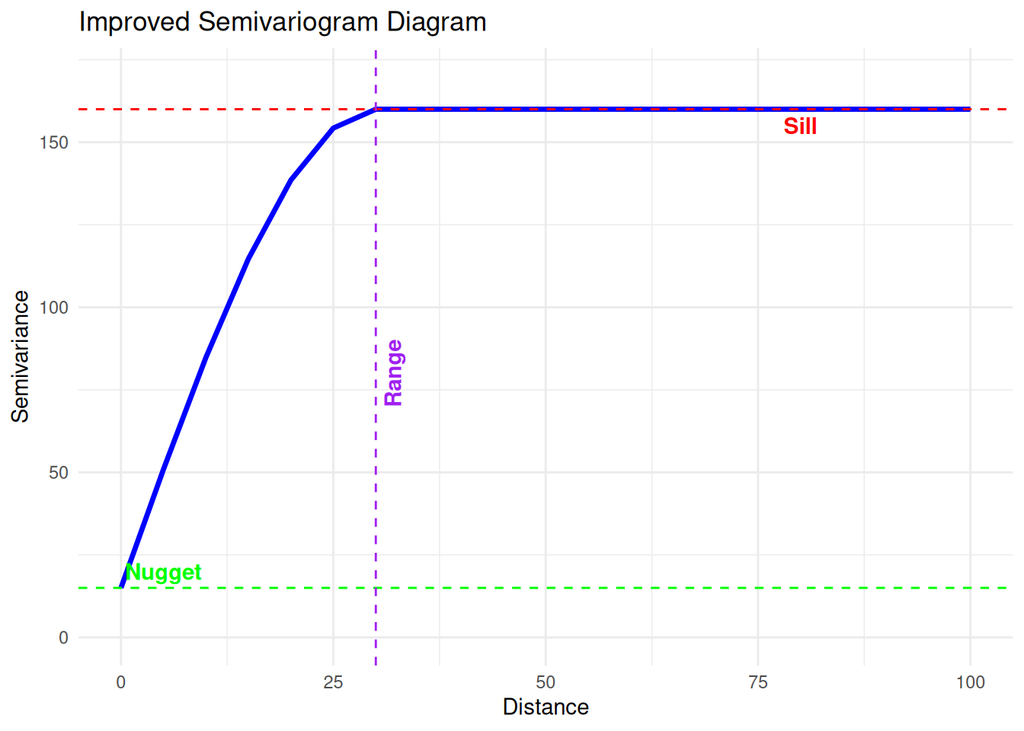

# **Basic Variogram Statistics**

### **1. Sill - Nugget**

- Measures the structured spatial variance.
- **Large value** → Strong spatial structure.
- **Small value** → Weak spatial dependence.

### **2. Relative Nugget Effect (Nugget/Sill)**

- **High (~1)** → Mostly random noise.
- **Low (~0)** → Strong spatial structure.

### **3. Range-to-Distance Ratio (Range / Max Distance)**

- **Close to 1** → Strong correlation across the study area.
- **Close to 0** → Correlation fades quickly.

### **4. Partial Sill (Sill - Nugget)**

- Measures the variance **explained by spatial dependence**.

### **5. Proportion of Spatially Structured Variation**

- **Formula:** Partial Sill / Sill.
- **Close to 1** → Mostly structured.
- **Close to 0** → Mostly random.

### **6. Mean Variogram Value Over Specific Lag Distances**

- Helps analyze how spatial dependence changes at different distances.

### **8. Anisotropy**

- Sometimes spatial dependence varies by direction, a phenomenon known as **anisotropy**.
- To measure anisotropy, we can compute variograms along different angles (e.g., **0°, 45°, 90°**).
- If spatial correlation differs by direction, we can quantify it using **anisotropy ratios**.

# **Working Through a Real Example: The Meuse Dataset**

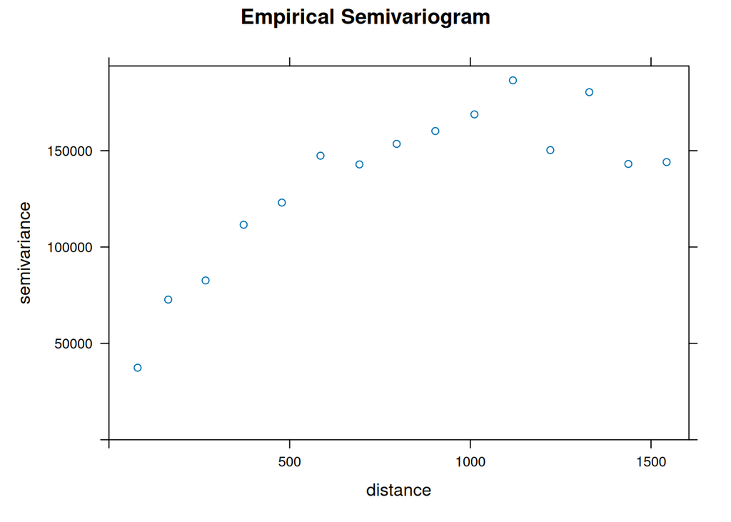

```r
library(sp)
library(gstat)

data(meuse, package = "sp")
coordinates(meuse) <- ~x+y  # Define spatial coordinates

# Compute the Empirical Variogram
variogram_model <- variogram(zinc ~ 1, meuse)
plot(variogram_model, main = "Empirical Semivariogram")
```

```r
# Fit a Variogram Model
vgm_model_nugget <- fit.variogram(variogram_model,
                                  vgm(psill = 10000, model = "Nug", range = 0, add.to =
                                      vgm(psill = 150000, model = "Sph", range = 600)))
print(vgm_model_nugget)
```

```
##   model     psill    range
## 1   Sph 134743.02 830.8819
## 2   Nug  24797.86   0.0000
```

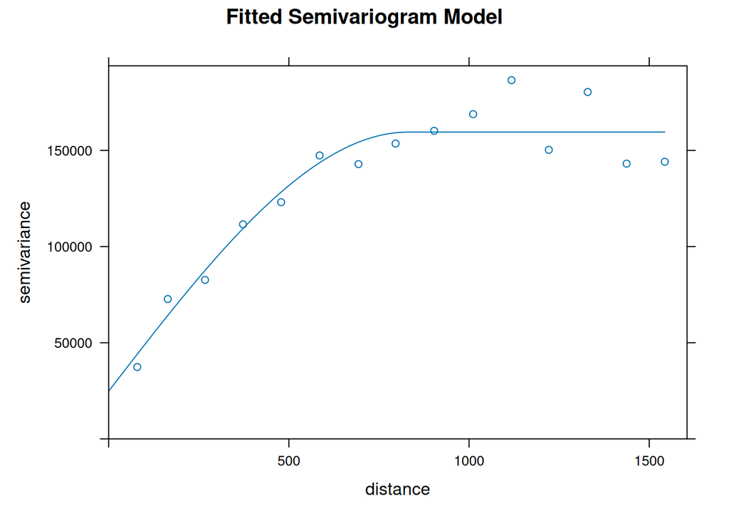

```r
plot(variogram_model, vgm_model_nugget, main = "Fitted Semivariogram Model")
```

# Next Step

For practice with your own CSV data (and side-by-side comparison of correlograms and semivariograms), see:

- [Spatial Dependence Part 2 repo](https://github.com/parker-group/spatial_depend_2)
- [Live tutorial site](https://parker-group.github.io/spatial_depend_2/)

### **Rendering the RMarkdown File**

Run in R:

```r
rmarkdown::render("variogram_tutorial1.Rmd")
```

This will create a Markdown file that you can push to GitHub.